# R Notebook

```r
library(tidyverse)
library(broom)
library(factoextra)
library(GGally)
```

```r
mall <- read_csv("data/mall_customers.csv") %>% janitor::clean_names()
```

```r
mall_target <- mall %>%
  select(annual_income_k, spending_score_1_100)
```

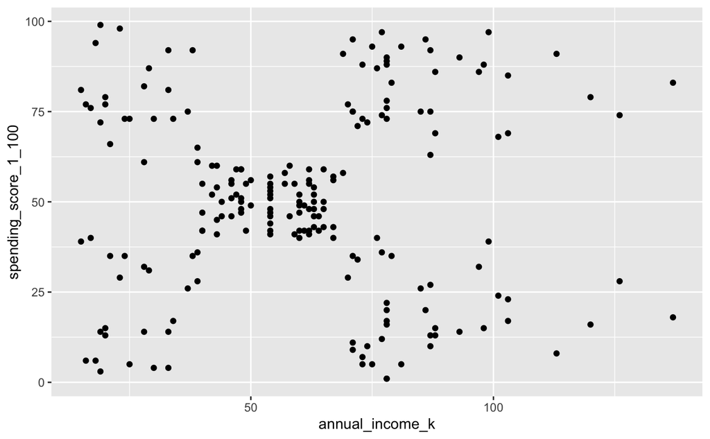

```r
mall_target %>%
  ggplot(aes(x = annual_income_k,
             y = spending_score_1_100))+
  geom_point()
```

findings:

- low annual income, low spending score group
- low annual income, high spending score group
- middle annual income, middle spending score group
- high annual income, low spending score group
- high annual income, high spending score group

k-means clustering

```r
max_k <- 20

k_clusters <- tibble(k = 1:max_k) %>%
  mutate(
    kclust = map(k, ~ kmeans(mall_target, .x, nstart = 25)),
    tidied = map(kclust, tidy),
    glanced = map(kclust, glance),
    augmented = map(kclust, augment, mall_target)
  )
```

```r
clusterings_target <- k_clusters %>%
  unnest(glanced)
```

Elbow

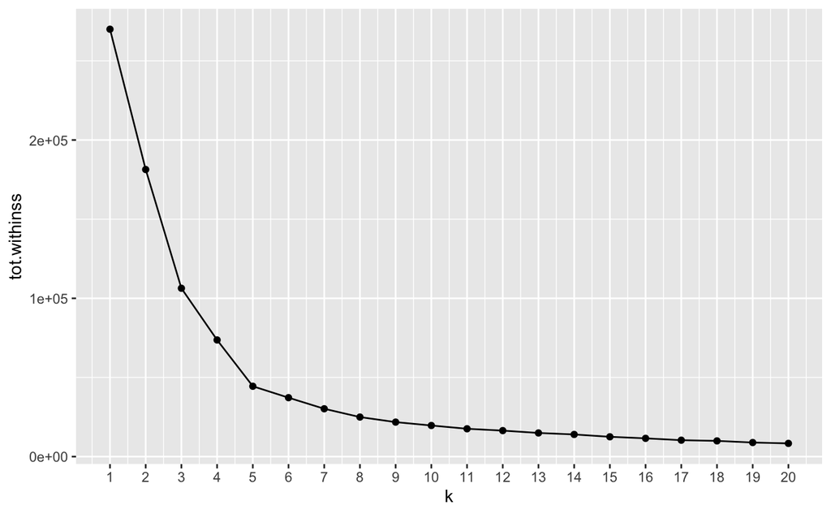

```r
clusterings_target %>%
  ggplot(aes(x = k,
             y = tot.withinss)) +
  geom_point() +
  geom_line() +
  scale_x_continuous(breaks = seq(1, 20, 1))
```

Observations:

- Elbow looks to be at k = 5

Silhouetting

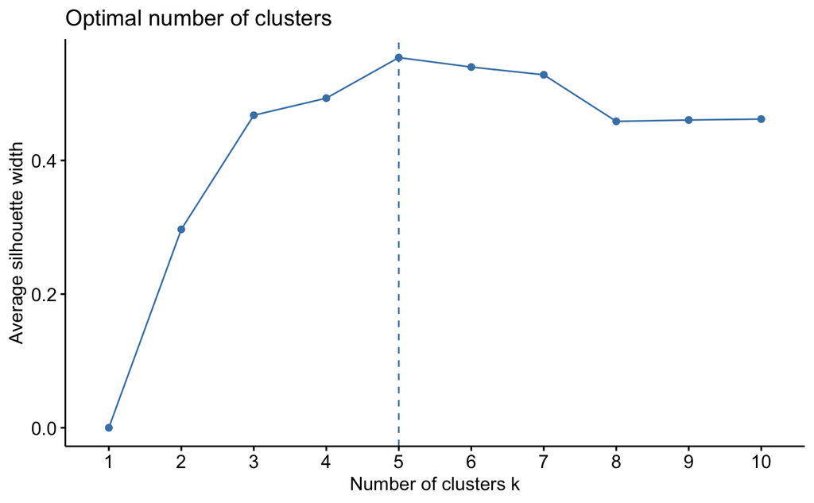

```r
library(factoextra)

fviz_nbclust(mall_target,
             kmeans,
             method = "silhouette",
             nstart = 25)
```

Observations:

- optimal number of clusters is given as 5
- same as the elbow point from the plot above

Gap Statistic

```
Clustering k = 1,2,..., K.max (= 10): .. done
Bootstrapping, b = 1,2,..., B (= 100)  [one "." per sample]:
.................................................. 50
.................................................. 100
```

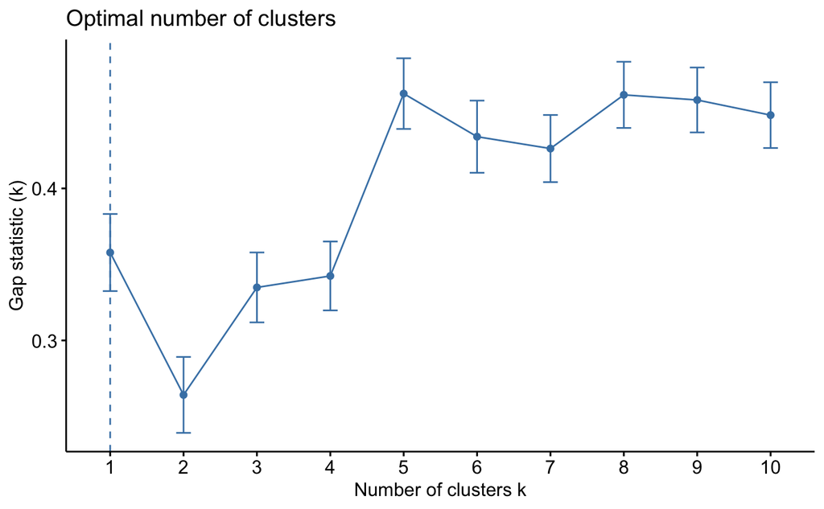

```r
fviz_nbclust(mall_target,
             kmeans,
             method = "gap_stat",
             nstart = 25)
```

Observations:

- optimal number of clusterings is given as 1
- not in agreement with first 2 plots

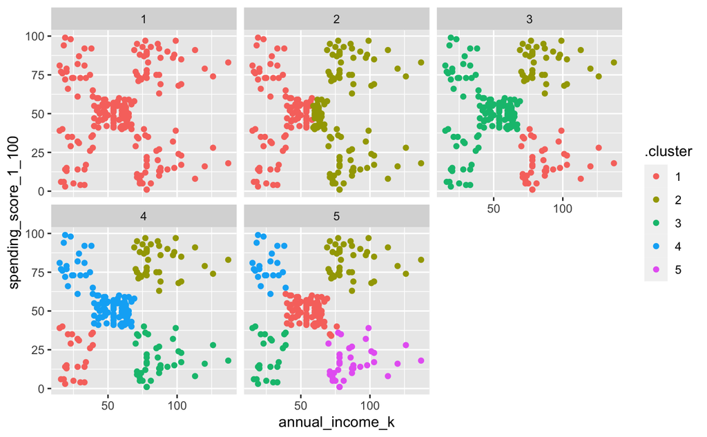

```r
clusterings_target %>%
  unnest(cols = c(augmented)) %>%
  filter(k <= 5) %>%
  ggplot(aes(x = annual_income_k,
             y = spending_score_1_100)) +
  geom_point(aes(colour = .cluster)) +
  facet_wrap(~ k)
```

Observations:

- cluster k = 5 visually looks to be the best split

Extract the means

```r
clusterings_target %>%
  unnest(augmented) %>%
  filter(k == 5) %>%
  group_by(.cluster) %>%
  summarise(mean(annual_income_k),
            mean(spending_score_1_100))
```

| .cluster | mean(annual_income_k) | mean(spending_score_1_100) |
| --- | --- | --- |
| 1 | 55.29630 | 49.51852 |
| 2 | 86.53846 | 82.12821 |
| 3 | 26.30435 | 20.91304 |
| 4 | 25.72727 | 79.36364 |
| 5 | 88.20000 | 17.11429 |

Observations

- k==3 and k==4 have a very similar mean annual income
- k==2 and k==5 have a very similar mean annual income
- k==2 and k==4 have a very similar mean spending score
- k==3 and k==5 have a very similar mean spending score
- none of the clusters have similar means for both variables

Results:

- clustering seems to be a good fit
- 2/3 of the plots show k = 5 to be the optimal number of clusterings
- the facet-wrap plot also shows that k = 5 is a good choice
- comparing the means backs this up too

Labels:

- cluster 1: Steadyeddie
- cluster 2: Big Spenders
- cluster 3: Survivors
- cluster 4: Champagne Lifestyle, Lemonade Budget
- cluster 5: Frugal